# Interaction analysis in emmeans

emmeans package, Version 2.0.1

Models in which predictors interact seem to create a lot of confusion concerning what kinds of *post hoc* methods should be used. It is hoped that this vignette will be helpful in shedding some light on how to use the **emmeans** package effectively in such situations.

## Contents

1. Interacting factors
   1. Simple contrasts
2. Interaction contrasts
3. Multivariate contrasts
4. Interactions with covariates
5. Summary

Index of all vignette topics

## Interacting factors

As an example for this topic, consider the `auto.noise` dataset included with the package. This is a balanced 3x2x2 experiment with three replications. The response – noise level – is evaluated with different sizes of cars, types of anti-pollution filters, on each side of the car being measured.[^1]

Let’s fit a model and obtain the ANOVA table (because of the scale of the data, we believe that the response is recorded in tenths of decibels; so we compensate for this by scaling the response):

```r
noise.lm <- lm(noise/10 ~ size * type * side, data = auto.noise)
anova(noise.lm)
```

```
## Analysis of Variance Table
##
## Response: noise/10
##                Df  Sum Sq Mean Sq  F value    Pr(>F)
## size            2 260.514 130.257 893.1905 < 2.2e-16
## type            1  10.563  10.563  72.4286 1.038e-08
## side            1   0.007   0.007   0.0476 0.8291042
## size:type       2   8.042   4.021  27.5714 6.048e-07
## size:side       2  12.931   6.465  44.3333 8.730e-09
## type:side       1   0.174   0.174   1.1905 0.2860667
## size:type:side  2   3.014   1.507  10.3333 0.0005791
## Residuals      24   3.500   0.146
```

There are statistically strong 2- and 3-way interactions.

One mistake that a lot of people seem to make is to proceed too hastily to estimating marginal means (even in the face of all these interactions!). They would go straight to analyses like this:

```r
emmeans(noise.lm, pairwise ~ size)
```

```
## NOTE: Results may be misleading due to involvement in interactions
```

```
## $emmeans
##  size emmean   SE df lower.CL upper.CL
##  S     82.42 0.11 24    82.19    82.64
##  M     83.38 0.11 24    83.15    83.60
##  L     77.25 0.11 24    77.02    77.48
##
## Results are averaged over the levels of: type, side
## Confidence level used: 0.95
##
## $contrasts
##  contrast estimate    SE df t.ratio p.value
##  S - M      -0.958 0.156 24  -6.147 <0.0001
##  S - L       5.167 0.156 24  33.140 <0.0001
##  M - L       6.125 0.156 24  39.287 <0.0001
##
## Results are averaged over the levels of: type, side
## P value adjustment: tukey method for comparing a family of 3 estimates
```

The analyst-in-a-hurry would thus conclude that the noise level is higher for medium-sized cars than for small or large ones.

But as is seen in the message before the output, `emmeans()` valiantly tries to warn you that it may not be a good idea to average over factors that interact with the factor of interest. It isn’t *always* a bad idea to do this, but sometimes it definitely is.

What about this time? I think a good first step is always to try to visualize the nature of the interactions before doing any statistical comparisons. The following plot helps.

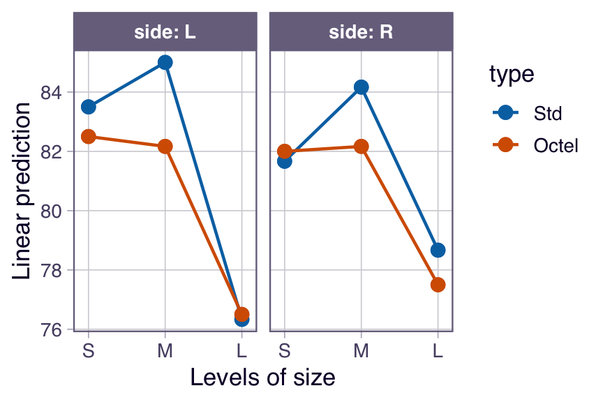

```r
emmip(noise.lm, type ~ size | side)
```

Examining this plot, we see that the “medium” mean is not always higher; so the marginal means, and the way they compare, does not represent what is always the case. Moreover, what is evident in the plot is that the peak for medium-size cars occurs for only one of the two filter types. So it seems more useful to do the comparisons of size separately for each filter type. This is easily done, simply by conditioning on `type`:

```r
emm_s.t <- emmeans(noise.lm, pairwise ~ size | type)
```

```
## NOTE: Results may be misleading due to involvement in interactions
```

```r
emm_s.t
```

```
## $emmeans
## type = Std:
##  size emmean    SE df lower.CL upper.CL
##  S     82.58 0.156 24    82.26    82.91
##  M     84.58 0.156 24    84.26    84.91
##  L     77.50 0.156 24    77.18    77.82
##
## type = Octel:
##  size emmean    SE df lower.CL upper.CL
##  S     82.25 0.156 24    81.93    82.57
##  M     82.17 0.156 24    81.84    82.49
##  L     77.00 0.156 24    76.68    77.32
##
## Results are averaged over the levels of: side
## Confidence level used: 0.95
##
## $contrasts
## type = Std:
##  contrast estimate   SE df t.ratio p.value
##  S - M     -2.0000 0.22 24  -9.071 <0.0001
##  S - L      5.0833 0.22 24  23.056 <0.0001
##  M - L      7.0833 0.22 24  32.127 <0.0001
##
## type = Octel:
##  contrast estimate   SE df t.ratio p.value
##  S - M      0.0833 0.22 24   0.378  0.9245
##  S - L      5.2500 0.22 24  23.812 <0.0001
##  M - L      5.1667 0.22 24  23.434 <0.0001
##
## Results are averaged over the levels of: side
## P value adjustment: tukey method for comparing a family of 3 estimates
```

Not too surprisingly, the statistical comparisons are all different for standard filters, but with Octel filters, there isn’t much of a difference between small and medium size.

For comparing the levels of other factors, similar judgments must be made. It may help to construct other interaction plots with the factors in different roles. In my opinion, almost all meaningful statistical analysis should be grounded in evaluating the practical impact of the estimated effects *first*, and seeing if the statistical evidence backs it up. Those who put all their attention on how many asterisks (I call these people “`*` gazers”) are ignoring the fact that these don’t measure the sizes of the effects on a practical scale.[^2] An effect can be practically negligible and still have a very small *P* value – or practically important but have a large *P* value – depending on sample size and error variance. Failure to describe what is actually going on in the data is a failure to do an adequate analysis. Use lots of plots, and *think* about the results. For more on this, see the discussion of *P* values in the “basics” vignette.

### Simple contrasts

An alternative way to specify conditional contrasts or comparisons is through the use of the `simple` argument to `contrast()` or `pairs()`, which amounts to specifying which factors are *not* used as `by` variables. For example, consider:

```r
noise.emm <- emmeans(noise.lm, ~ size * side * type)
```

Then `pairs(noise.emm, simple = "size")` is the same as `pairs(noise.emm, by = c("side", "type"))`.

One may specify a list for `simple`, in which case separate runs are made with each element of the list. Thus, `pairs(noise.emm, simple = list("size", c("side", "type"))` returns two sets of contrasts: comparisons of `size` for each combination of the other two factors; and comparisons of `side*type` combinations for each `size`.

A shortcut that generates all simple main-effect comparisons is to use `simple = "each"`. In this example, the result is the same as obtained using `simple = list("size", "side", "type")`.

Ordinarily, when `simple` is a list (or equal to `"each"`), a list of contrast sets is returned. However, if the additional argument `combine` is set to `TRUE`, they are all combined into one family:

```r
contrast(noise.emm, "consec", simple = "each", combine = TRUE, adjust = "mvt")
```

```
##  side type  size contrast    estimate    SE df t.ratio p.value
##  L    Std   .    M - S          1.500 0.312 24   4.811  0.0013
##  L    Std   .    L - M         -8.667 0.312 24 -27.795 <0.0001
##  R    Std   .    M - S          2.500 0.312 24   8.018 <0.0001
##  R    Std   .    L - M         -5.500 0.312 24 -17.639 <0.0001
##  L    Octel .    M - S         -0.333 0.312 24  -1.069  0.9768
##  L    Octel .    L - M         -5.667 0.312 24 -18.174 <0.0001
##  R    Octel .    M - S          0.167 0.312 24   0.535  0.9999
##  R    Octel .    L - M         -4.667 0.312 24 -14.967 <0.0001
##  .    Std   S    R - L         -1.833 0.312 24  -5.880  0.0001
##  .    Std   M    R - L         -0.833 0.312 24  -2.673  0.1714
##  .    Std   L    R - L          2.333 0.312 24   7.483 <0.0001
##  .    Octel S    R - L         -0.500 0.312 24  -1.604  0.7744
##  .    Octel M    R - L          0.000 0.312 24   0.000  1.0000
##  .    Octel L    R - L          1.000 0.312 24   3.207  0.0562
##  L    .     S    Octel - Std   -1.000 0.312 24  -3.207  0.0569
##  L    .     M    Octel - Std   -2.833 0.312 24  -9.087 <0.0001
##  L    .     L    Octel - Std    0.167 0.312 24   0.535  0.9999
##  R    .     S    Octel - Std    0.333 0.312 24   1.069  0.9768
##  R    .     M    Octel - Std   -2.000 0.312 24  -6.414 <0.0001
##  R    .     L    Octel - Std   -1.167 0.312 24  -3.742  0.0167
##
## P value adjustment: mvt method for 20 tests
```

The dots (`.`) in this result correspond to which simple effect is being displayed. If we re-run this same call with `combine = FALSE` or omitted, these twenty comparisons would be displayed in three broad sets of contrasts, each broken down further by combinations of `by` variables, each separately multiplicity-adjusted (a total of 16 different tables).

Back to Contents

## Interaction contrasts

An interaction contrast is a contrast of contrasts. For instance, in the auto-noise example, we may want to obtain the linear and quadratic contrasts of `size` separately for each `type`, and compare them. Here are estimates of those contrasts:

```r
contrast(emm_s.t[[1]], "poly")   ## 'by = "type"' already in previous result
```

```
## type = Std:
##  contrast  estimate    SE df t.ratio p.value
##  linear       -5.08 0.220 24 -23.056 <0.0001
##  quadratic    -9.08 0.382 24 -23.786 <0.0001
##
## type = Octel:
##  contrast  estimate    SE df t.ratio p.value
##  linear       -5.25 0.220 24 -23.812 <0.0001
##  quadratic    -5.08 0.382 24 -13.311 <0.0001
##
## Results are averaged over the levels of: side
```

The comparison of these contrasts may be done using the `interaction` argument in `contrast()` as follows:

```r
IC_st <- contrast(emm_s.t[[1]], interaction = c("poly", "consec"), by = NULL)
IC_st
```

```
##  size_poly type_consec estimate    SE df t.ratio p.value
##  linear    Octel - Std   -0.167 0.312 24  -0.535  0.5979
##  quadratic Octel - Std    4.000 0.540 24   7.407 <0.0001
##
## Results are averaged over the levels of: side
```

(Using `by = NULL` restores `type` to a primary factor in these contrasts.) The practical meaning of this is that there isn’t a statistical difference in the linear trends, but the quadratic trend for Octel is greater than for standard filter types. (Both quadratic trends are negative, so in fact it is the standard filters that have more pronounced *downward* curvature, as is seen in the plot.) In case you need to understand more clearly what contrasts are being estimated, the `coef()` method helps:

```r
coef(IC_st)
```

```
##   size  type c.1 c.2
## 1    S   Std   1  -1
## 2    M   Std   0   2
## 3    L   Std  -1  -1
## 4    S Octel  -1   1
## 5    M Octel   0  -2
## 6    L Octel   1   1
```

Note that the 4th through 6th contrast coefficients are the negatives of the 1st through 3rd – thus a comparison of two contrasts.

By the way, “type III” tests of interaction effects can be obtained via interaction contrasts:

```r
test(IC_st, joint = TRUE)
```

```
##  df1 df2 F.ratio p.value
##    2  24  27.571 <0.0001
```

This result is exactly the same as the *F* test of `size:type` in the `anova` output.

The three-way interaction may be explored via interaction contrasts too:

```r
emmeans(noise.lm, ~ size*type*side) |>
    contrast(interaction = c("poly", "consec", "consec"))
```

```
##  size_poly type_consec side_consec estimate    SE df t.ratio p.value
##  linear    Octel - Std R - L          -2.67 0.624 24  -4.276  0.0003
##  quadratic Octel - Std R - L          -1.67 1.080 24  -1.543  0.1359
```

One interpretation of this is that the comparison by `type` of the linear contrasts for `size` is different on the left side than on the right side; but the comparison of that comparison of the quadratic contrasts, not so much. Refer again to the plot, and this can be discerned as a comparison of the interaction in the left panel versus the interaction in the right panel.

Finally, **emmeans** provides a `joint_tests()` function that obtains and tests the interaction contrasts for all effects in the model and compiles them in one Type-III-ANOVA-like table:

```r
joint_tests(noise.lm)
```

```
##  model term     df1 df2 F.ratio p.value
##  size             2  24 893.190 <0.0001
##  type             1  24  72.429 <0.0001
##  side             1  24   0.048  0.8291
##  size:type        2  24  27.571 <0.0001
##  size:side        2  24  44.333 <0.0001
##  type:side        1  24   1.190  0.2861
##  size:type:side   2  24  10.333  0.0006
```

You may even add `by` variable(s) to obtain separate ANOVA tables for the remaining factors:

```r
joint_tests(noise.lm, by = "side")
```

```
## side = L:
##  model term df1 df2 F.ratio p.value
##  size         2  24 651.714 <0.0001
##  type         1  24  46.095 <0.0001
##  size:type    2  24  23.524 <0.0001
##
## side = R:
##  model term df1 df2 F.ratio p.value
##  size         2  24 285.810 <0.0001
##  type         1  24  27.524 <0.0001
##  size:type    2  24  14.381 <0.0001
```

Back to Contents

## Multivariate contrasts

In the preceding sections, the way we addressed interacting factors was to do comparisons or contrasts of some factors()) separately at levels of other factor(s). This leads to a lot of estimates and associated tests.

```r
mvcontrast(noise.emm, "pairwise", mult.name = c("type", "side"))
```

```
##  contrast T.square df1 df2 F.ratio p.value
##  S - M      88.857   4  21  19.438 <0.0001
##  S - L    1199.429   4  21 262.375 <0.0001
##  M - L    1638.000   4  21 358.312 <0.0001
##
## P value adjustment: sidak
```

In this output, the `T.square` values are Hotelling’s $T^2$ statistics, which are the squared Mahalanobis distances among the sets of four means. These results thus accomplish a similar objective as the initial comparisons presented in this vignette, but are not complicated by the issue that the factors interact. (Instead, we lose the directionality of the comparisons.) While all comparisons are “significant,” the `T.square` values indicate that large cars are statistically most different from the other sizes.

We may still break things down using `by` variables. Suppose, for example, we wish to compare the two filter types for each size of car, without regard to which side:

```r
update(mvcontrast(noise.emm, "consec", mult.name = "side", by = "size"),
       by = NULL)
```

```
##  contrast    size T.square df1 df2 F.ratio p.value
##  Octel - Std S      11.429   2  23   5.476  0.0113
##  Octel - Std M     123.714   2  23  59.280 <0.0001
##  Octel - Std L      14.286   2  23   6.845  0.0047
##
## P value adjustment: sidak
```

One detail to note about multivariate comparisons: in order to make complete sense, all the factors involved must interact. Suppose we were to repeat the initial multivariate comparison after removing all interactions:

```r
mvcontrast(update(noise.emm, submodel = ~ side + size + type),
           "pairwise", mult.name = c("type", "side"))
```

```
##  contrast T.square df1 df2  F.ratio p.value
##  S - M      37.786   1  24   37.786 <0.0001
##  S - L    1098.286   1  24 1098.286 <0.0001
##  M - L    1543.500   1  24 1543.500 <0.0001
##
## P value adjustment: sidak
## NOTE: Some or all d.f. are reduced due to singularities
```

Note that each $F$ ratio now has 1 d.f. Also, note that `T.square = F.ratio`, and you can verify that these values are equal to the squares of the `t.ratio`s in the initial example in this vignette ($(-6.147)^2 = 37.786$, etc.). That is, if we ignore all interactions, the multivariate tests are exactly equivalent to the univariate tests of the marginal means.

Back to Contents

## Interactions with covariates

When a covariate and a factor interact, we typically don’t want EMMs themselves, but rather estimates of *slopes* of the covariate trend for each level of the factor. As a simple example, consider the `fiber` dataset, and fit a model including the interaction between `diameter` (a covariate) and `machine` (a factor):

```r
fiber.lm <- lm(strength ~ diameter*machine, data = fiber)
```

This model comprises fitting, for each machine, a separate linear trend for `strength` versus `diameter`. Accordingly, we can estimate and compare the slopes of those lines via the `emtrends()` function:

```r
emtrends(fiber.lm, pairwise ~ machine, var = "diameter")
```

```
## $emtrends
##  machine diameter.trend    SE df lower.CL upper.CL
##  A                1.104 0.194  9    0.666     1.54
##  B                0.857 0.224  9    0.351     1.36
##  C                0.864 0.208  9    0.394     1.33
##
## Confidence level used: 0.95
##
## $contrasts
##  contrast estimate    SE df t.ratio p.value
##  A - B     0.24714 0.296  9   0.835  0.6919
##  A - C     0.24008 0.284  9   0.845  0.6863
##  B - C    -0.00705 0.306  9  -0.023  0.9997
##
## P value adjustment: tukey method for comparing a family of 3 estimates
```

We see the three slopes, but no two of them test as being statistically different.

To visualize the lines themselves, you may use

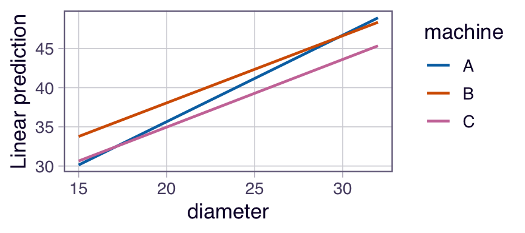

```r
emmip(fiber.lm, machine ~ diameter, cov.reduce = range)
```

The `cov.reduce = range` argument is passed to `ref_grid()`; it is needed because by default, each covariate is reduced to only one value (see the “basics” vignette). Instead, we call the `range()` function to obtain the minimum and maximum diameter.

For a more sophisticated example, consider the `oranges` dataset included with the package. These data concern the sales of two varieties of oranges. The prices (`price1` and `price2`) were experimentally varied in different stores and different days, and the responses `sales1` and `sales2` were observed. Let’s consider three multivariate models for these data, with additive effects for days and stores, and different levels of fitting on the prices:

```r
org.quad <- lm(cbind(sales1, sales2) ~ poly(price1, price2, degree = 2)
                                       + day + store, data = oranges)
org.int <- lm(cbind(sales1, sales2) ~ price1 * price2 + day + store, data = oranges)
org.add <- lm(cbind(sales1, sales2) ~ price1 + price2 + day + store, data = oranges)
```

Being a multivariate model, **emmeans** methods will distinguish the responses as if they were levels of a factor, which we will name “variety”. Moreover, separate effects are estimated for each multivariate response, so there is an *implied interaction* between `variety` and each of the predictors involving `price1` and `price2`. (In `org.int`, there is an implied three-way interaction.) An interesting way to view these models is to look at how they predict sales of each variety at each observed values of the prices:

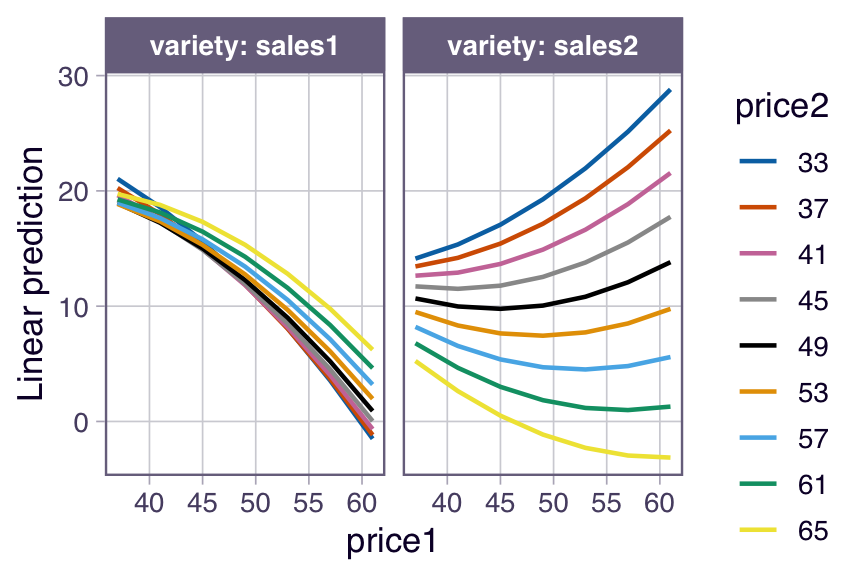

```r
emmip(org.quad, price2 ~ price1 | variety, mult.name = "variety", cov.reduce = FALSE)
```

The trends portrayed here are quite sensible: In the left panel, as we increase the price of variety 1, sales of that variety will tend to decrease – and the decrease will be faster when the other variety of oranges is low-priced. In the right panel, as price of variety 1 increases, sales of variety 2 will increase when it is low-priced, but could decrease also at high prices because oranges in general are just too expensive. A plot like this for `org.int` will be similar but all the curves will be straight lines; and the one for `plot.add` will have all lines parallel. In all models, though, there are implied `price1:variety` and `price2:variety` interactions, because we have different regression coefficients for the two responses.

Which model should we use? They are nested models, so they can be compared by `anova()`:

```r
anova(org.quad, org.int, org.add)
```

```
## Analysis of Variance Table
##
## Model 1: cbind(sales1, sales2) ~ poly(price1, price2, degree = 2) + day +
##     store
## Model 2: cbind(sales1, sales2) ~ price1 * price2 + day + store
## Model 3: cbind(sales1, sales2) ~ price1 + price2 + day + store
##   Res.Df Df Gen.var.   Pillai approx F num Df den Df Pr(>F)
## 1     20      22.798
## 2     22  2   21.543 0.074438  0.38658      4     40 0.8169
## 3     23  1   23.133 0.218004  2.64840      2     19 0.0967
```

It seems like the full-quadratic model has little advantage over the interaction model. There truly is nothing magical about a *P* value of 0.05, and we have enough data that over-fitting is not a hazard; so I like `org.int`. However, what follows could be done with any of these models.

To summarize and test the results compactly, it makes sense to obtain estimates of a representative trend in each of the left and right panels, and perhaps to compare them. In turn, that can be done by obtaining the slope of the curve (or line) at the average value of `price2`. The `emtrends()` function is designed for exactly this kind of purpose. It uses a difference quotient to estimate the slope of a line fitted to a given variable. It works just like `emmeans()` except for requiring the variable to use in the difference quotient. Using the `org.int` model:

```r
emtrends(org.int, pairwise ~ variety, var = "price1", mult.name = "variety")
```

```
## $emtrends
##  variety price1.trend    SE df lower.CL upper.CL
##  sales1        -0.749 0.171 22   -1.104   -0.394
##  sales2         0.138 0.214 22   -0.306    0.582
##
## Results are averaged over the levels of: day, store
## Confidence level used: 0.95
##
## $contrasts
##  contrast        estimate   SE df t.ratio p.value
##  sales1 - sales2   -0.887 0.24 22  -3.690  0.0013
##
## Results are averaged over the levels of: day, store
```

From this, we can say that, starting with `price1` and `price2` both at their average values, we expect `sales1` to decrease by about .75 per unit increase in `price1`; meanwhile, there is a suggestion of a slight increase of `sales2`, but without much statistical evidence. Marginally, the first variety has a 0.89 disadvantage relative to sales of the second variety.

Other analyses (not shown) with `price2` set at a higher value will reduce these effects, while setting `price2` lower will exaggerate all these effects. If the same analysis is done with the quadratic model, the the trends are curved, and so the results will depend somewhat on the setting for `price1`. The graph above gives an indication of the nature of those changes.

Similar results hold when we analyze the trends for `price2`:

```r
emtrends(org.int, pairwise ~ variety, var = "price2", mult.name = "variety")
```

```
## $emtrends
##  variety price2.trend    SE df lower.CL upper.CL
##  sales1         0.172 0.102 22  -0.0404    0.384
##  sales2        -0.745 0.128 22  -1.0099   -0.480
##
## Results are averaged over the levels of: day, store
## Confidence level used: 0.95
##
## $contrasts
##  contrast        estimate    SE df t.ratio p.value
##  sales1 - sales2    0.917 0.143 22   6.387 <0.0001
##
## Results are averaged over the levels of: day, store
```

At the averages, increasing the price of variety 2 has the effect of decreasing sales of variety 2 while slightly increasing sales of variety 1 – a marginal difference of about .92.

Back to Contents

## Summary

Interactions, by nature, make things more complicated. One must resist pressures and inclinations to try to produce simple bottom-line conclusions. Interactions require more work and more patience; they require presenting more cases – more than are presented in the examples in this vignette – in order to provide a complete picture.

Index of all vignette topics

[^1]: I sure wish I could ask some questions about how how these data were collected; for example, are these independent experimental runs, or are some cars measured more than once? The model is based on the independence assumption, but I have my doubts.
[^2]: You may have noticed that there are no asterisks in the ANOVA table in this vignette. I habitually opt out of star-gazing by including `options(show.signif.stars = FALSE)` in my `.Rprofile` file.